# MBECS Haptoglobin

Gabriela Puerres

2025-07-18

# **Evaluation and correction of batch effects in microbiome data-sets**

- Package ‘MBECS’ Version 1.12.0
- Description: The Microbiome Batch Effect Correction Suite (MBECS) provides a set of functions to evaluate and mitigate unwated noise due to processing in batches. To that end it incorporates a host of batch correcting algorithms (BECA) from various packages. In addition it offers a correction and reporting pipeline that provides a preliminary look at the characteristics of a data-set before and after correcting for batch effects.

## **References:**

- Olbrich M (2025). *MBECS: Evaluation and correction of batch effects in microbiome data-sets*. [doi:10.18129/B9.bioc.MBECS](https://doi.org/10.18129/B9.bioc.MBECS), R package version 1.12.0, https://bioconductor.org/packages/MBECS.

URLS

- GitHub: https://github.com/rmolbrich/MBECS
- MBECS workflow: https://www.bioconductor.org/packages/release/bioc/vignettes/MBECS/inst/doc/mbecs_vignette.html
- Documentation: https://www.bioconductor.org/packages/release/bioc/html/MBECS.html

## **Libraries**

```r
library(MBECS)
library (phyloseq)
library(dplyr)
library(Biostrings)
```

The user can utilize objects of class `phyloseq` or a `list` object that contains an abundance table as well as meta data. The package contains a dummy data-set of artificially generated data to illustrate this process. To start an analysis, the user requires the `mbecProcessInput()` function.

## **DATA:**

```r
# Phyloseq object
ps <- readRDS("~/Cow_Inflammation_Study/Confounders/ps.st.decontam.rds")
ps <- subset_samples(ps, Sample_Type == "Feces")
ps
```

```
## phyloseq-class experiment-level object
## otu_table()   OTU Table:         [ 21727 taxa and 142 samples ]
## sample_data() Sample Data:       [ 142 samples by 68 sample variables ]
## tax_table()   Taxonomy Table:    [ 21727 taxa by 7 taxonomic ranks ]
```

```r
# As the names of the sequences in the OTU table is the sequence itself.A name as ASVxx will be assigned:
old_seqs <- taxa_names(ps)
new_ids  <- paste0("ASV", seq_along(old_seqs))
taxa_names(ps) <- new_ids
```

## **1. Data from Phyloseq Object**

```r
#The dummy.ps object contains the same data as dummy.list, but it is of class phyloseq. Create an MbecData object from phyloseq input.

#The optional argument required.col may be used to ensure that all covariate columns that should be there are available. For the dummy-data these are “group”, “batch” and “replicate”.

mbec.obj <- mbecProcessInput(ps)
```

```
## No 'sID' column present, creating from rownames now.
```

```r
str(mbec.obj)
```

[output not shown]

[output cut: 46 more lines]

[output not shown]

## **2. Normalization**

The most common normalizing transformations in microbiome analysis are total sum scaling (TSS) and centered log-ratio transformation (CLR).

Hence, the `MBECS` package offers these two methods. The resulting matrices will be stored in their respective `slots (tss, clr)` in the `MbecData` object, while the original abundance table will remain unchanged.

Use `mbecTransform()` to apply total sum scaling to the data. Apply centered log-ratio transformation to the data. Due to the sparse nature of compositional microbiome data, the parameter `offset` may be used to add a small offset to the abundance matrix in order to facilitate the CLR transformation.

[output not shown]

```r
mbec.obj  <- mbecTransform(mbec.obj, method = "tss")
```

```
## Set tss-transformed counts.
```

[output not shown]

```r
mbec.obj  <- mbecTransform(mbec.obj, method = "clr", offset = 0.0001)
```

## **3. Preliminary Report**

The function `mbecReportPrelim()` will provide the user with an overview of experimental setup and the significance of the batch effect. To that end it is required to declare the covariates that are related to batch effect and group effect respectively. In addition it provides the option to select the abundance table to use here. The CLR transformed abundances are the default and the function will calculate them if they are not present in the input. Technically, the user can start the analysis at this point because the function incorporates the functionality of the aforementioned processing functions.

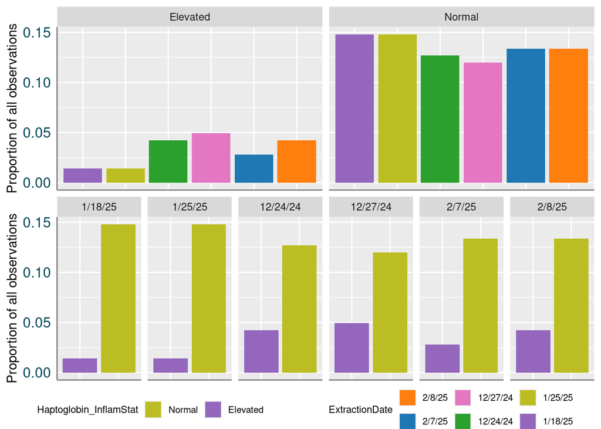

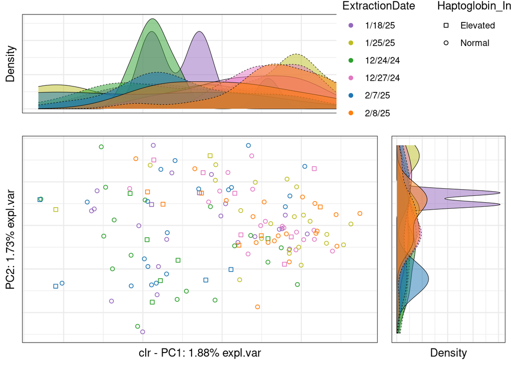

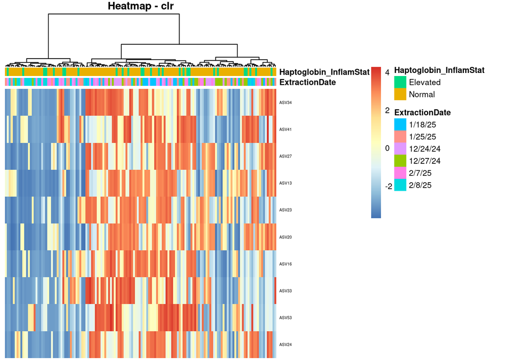

[output not shown]

[output not shown]

[output not shown]

[output not shown]

[output not shown]

[output not shown]

[output not shown]

[output not shown]

[output not shown]

[output not shown]

[output not shown]

[output not shown]

[output not shown]

[output not shown]

[output not shown]

[output not shown]

[output not shown]

[output not shown]

[output not shown]

[output not shown]

[output not shown]

[output not shown]

[output not shown]

[output not shown]

[output not shown]

[output not shown]

[output not shown]

[output not shown]

[output not shown]

[output not shown]

[output not shown]

[output not shown]

[output not shown]

[output not shown]

[output not shown]

[output not shown]

[output not shown]

[output not shown]

[output not shown]

[output not shown]

[output not shown]

[output not shown]

[output not shown]

[output not shown]

[output not shown]

[output not shown]

[output not shown]

[output not shown]

[output not shown]

[output not shown]

[output not shown]

[output not shown]

[output not shown]

[output not shown]

[output not shown]

[output not shown]

[output not shown]

[output not shown]

[output not shown]

[output not shown]

[output not shown]

[output not shown]

[output not shown]

[output not shown]

[output not shown]

[output not shown]

[output not shown]

[output not shown]

[output not shown]

[output not shown]

[output not shown]

[output not shown]

[output not shown]

[output not shown]

[output not shown]

[output not shown]

[output not shown]

[output not shown]

[output not shown]

[output not shown]

[output not shown]

[output not shown]

[output not shown]

[output not shown]

[output not shown]

[output not shown]

[output not shown]

[output not shown]

[output not shown]

[output not shown]

[output not shown]

[output not shown]

[output not shown]

[output not shown]

[output not shown]

[output not shown]

[output not shown]

[output not shown]

[output not shown]

[output not shown]

[output not shown]

```
## [1] "ExtractionDate"
## [1] "Haptoglobin_InflamStat"
```

[output not shown]

[output not shown]

[output not shown]

[output not shown]

[output not shown]

[output not shown]

[output not shown]

[output not shown]

[output not shown]

[output not shown]

[output not shown]

```r
mbecReportPrelim(input.obj=mbec.obj ,
                 model.vars=c("ExtractionDate",
                              "Haptoglobin_InflamStat"),
                 type="clr")
```

The parameter `model.vars` is a character vector with two elements. The first denotes the covariate column that describes the batch effect and the second one should be used for the presumed biological effect of interest, e.g., the group effect in case/control studies. The `type` parameter selects which abundance table is to be used “otu”, “clr”, “tss” .

## **4. Corrections (Select the type!)**

The package acts as a wrapper for six different batch effect correcting algorithms (BECA).

The user has the choice between two functions `mbecCorrection()` and `mbecRunCorrections()`, the latter one acts as a wrapper that can apply multiple correction methods in a single run. If the input to `mbecRunCorrections()` is missing CLR and TSS transformed abundance matrices, they will be created with default settings, i.e., offsets for zero values will be set to 1/#features.

```r
mbec.obj  <- mbecCorrection(mbec.obj , model.vars=c("ExtractionDate",
                                                    "Haptoglobin_InflamStat"),
                            method = "bat", type = "clr")
```

```
## Applying ComBat (sva) for batch-correction.
```

```
## Found6batches
```

```
## Adjusting for1covariate(s) or covariate level(s)
```

```
## Standardizing Data across genes
```

```
## Fitting L/S model and finding priors
```

```
## Finding nonparametric adjustments
```

```
## Adjusting the Data
```

```r
mbec.obj <- mbecCorrection(mbec.obj, model.vars = c("ExtractionDate",
                                                    "Haptoglobin_InflamStat"),
                               method = "ruv3", type = "clr")
```

```
## No negative control features provided.
##                 Using pseudo-negative controls.
```

```
## Applying Remove Unwanted Variantion v3 (RUV-III).
```

```r
mbec.obj <- mbecCorrection(mbec.obj, model.vars = c("ExtractionDate",
                                                    "Haptoglobin_InflamStat"),
                               method = "bmc", type = "clr")

mbec.obj <- mbecCorrection(mbec.obj, model.vars = c("ExtractionDate",
                                                    "Haptoglobin_InflamStat"),
                               method = "rbe", type = "clr")
```

```r
mbec.obj <- mbecCorrection(mbec.obj, model.vars = c("ExtractionDate",
                                                    "Haptoglobin_InflamStat"),
                               method = "pn", type = "clr")
```

```
## Applying Percentile Normalization (PN).
```

```
## Group Elevated is considered control group, i.e., reference
##           for normalization procedure. To change reference please 'relevel()'
##           grouping factor accordingly.
```

```r
mbec.obj <- mbecCorrection(mbec.obj, model.vars = c("ExtractionDate",
                                                    "Haptoglobin_InflamStat"),
                               method = "svd", type = "clr")
```

```
## Applying Singular Value Decomposition (SVD) for batch-correction.
```